# Kevin Martin & Ravjot Sachdev CIS663 - Wednesday @ 9:00pm EST

# 3. Data Preperation

## 3.1 Data Selection

We will be using 100% of the available data, and splitting it into train/test sets in section 4.

## 3.2 Clean The Data

### 3.2.1 Altering Data Types and Dealing with Zeros

There is no need to alter any data types, nor deal with excessive zeros.

### 3.2.2 Dealing With Duplicates

```python
print('Original shape of data')
print(df_all.shape)
print('Shape after removing duplicates')
df_all.drop_duplicates(keep='first')
print(df_all.shape)
```

```
Original shape of data
(5510, 6)
Shape after removing duplicates
(5510, 6)
```

## 3.2.3 Missing Values

No missing values to address.

```python
print(df_all.shape)
df.dropna(inplace=True)
print(df_all.shape)
```

```
(5510, 6)
(5510, 6)
```

```python
df_all[df_all.pid=='MC7070'].shape[0]
df_all.pid.shape[0]
```

```
5510
```

```python
#bk_data = inner[inner['pid']=='MC7070']
#time_data = bk_data['TAC_Reading']
#total = inner[inner.pid=='MC7070'].shape[0]
time_data = df_all.timestamp
total = df_all.TAC_Reading.shape[0]
test = int(round(total * .3))
train = total - test
buff = 80

prev_values = time_data.iloc[:12000]
y_train3 = time_data[buff:train]
y_test3 = time_data[train:]
X_train3 = pd.DataFrame([list(time_data[i:i+buff]) for i in range(train - buff)],
                       columns=range(buff,0,-1),index=y_train3.index)
X_test3 = pd.DataFrame([list(time_data[i:i+buff]) for i in range(train - buff,total - buff)],
                       columns=range(buff,0,-1),index=y_test3.index)

def plot_pred(pred,title):
    plt.figure(figsize=(17,5))
    plt.plot(prev_values,label='Train')
    plt.plot(y_test3,label='Actual')
    plt.plot(pred,label='Predicted')
    plt.ylabel("TAC")
    plt.title(title,fontsize=20)
    plt.legend()
    plt.show()
```

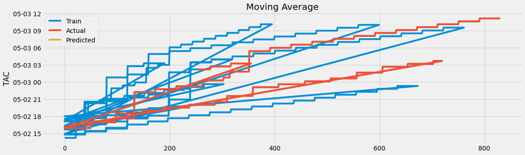

```python
y_ma = X_test3.mean(axis=1)
#print(mse(y_ma,y_test3))
plot_pred(y_ma,"Moving Average")
```

```python
#total = df[df.ticker=='BTC'].shape[0]
total = inner
test = int(round(total * .3))
train = total - test
buff = 80

prev_values = time_data.iloc[:1200]
y_train3 = time_data[buff:train]
y_test3 = time_data[train:]
X_train3 = pd.DataFrame([list(time_data[i:i+buff]) for i in range(train - buff)],
                       columns=range(buff,0,-1),index=y_train3.index)
X_test3 = pd.DataFrame([list(time_data[i:i+buff]) for i in range(train - buff,total - buff)],
                       columns=range(buff,0,-1),index=y_test3.index)

def plot_pred(pred,title):
    plt.figure(figsize=(17,5))
    plt.plot(prev_values,label='Train')
    plt.plot(y_test3,label='Actual')
    plt.plot(pred,label='Predicted')
    plt.ylabel("Stock prices")
    plt.title(title,fontsize=20)
    plt.legend()
    plt.show()
```

[output not shown]

# 4. Model Training/Testing

## 4.1 Multi-Class Testing

```python
"""
'binary':
Only report results for the class specified by pos_label. This is applicable only if targets (y_{true,pred}) are binary.

'micro':
Calculate metrics globally by counting the total true positives, false negatives and false positives.

'macro':
Calculate metrics for each label, and find their unweighted mean. This does not take label imbalance into account.

'weighted':
Calculate metrics for each label, and find their average weighted by support (the number of true instances for each label). This alters ‘macro’ to account for label imbalance; it can result in an F-score that is not between precision and recall.

'samples':
Calculate metrics for each instance, and find their average (only meaningful for multilabel classification where this differs from accuracy_score).
"""

metric_eval = 'macro'

# num_vars = df.select_dtypes(['float64']).columns
num_vars = ['x', 'y', 'z']
print('Columns to check: ', num_vars)
x = inner[num_vars]
y = inner.TAC_Reading

x_train, x_test, y_train, y_test = train_test_split(x, y, test_size=0.3, random_state=16)

scaler = StandardScaler().fit(x_train)
x_train = scaler.transform(x_train)
x_test = scaler.transform(x_test)

def evaluate(model, graph_flag):
    out_mod = model.fit(x_train, y_train)
    y_pred = model.predict(x_test)
    cm = confusion_matrix(y_test, y_pred)
    print ("Accuracy:", accuracy_score(y_test, y_pred))
    print("Precision:",metrics.precision_score(y_test, y_pred, average=metric_eval))
    print("Recall:",metrics.recall_score(y_test, y_pred, average=metric_eval))
    print("F1:", metrics.f1_score(y_test,y_pred, average=metric_eval))
    if graph_flag == 1:
        print ("Confusion Matrix: \n", cm)
        sns.heatmap(cm)
    return out_mod
```

```
Columns to check:  ['x', 'y', 'z']
```

```python
gnb = GaussianNB()
gnb_train = evaluate(gnb, 0)
```

[output not shown]

```python
%%time
dtc = DecisionTreeClassifier()
evaluate(dtc, 0)
```

[output not shown]

```python
%%time
from xgboost import XGBClassifier
xgb = XGBClassifier()
xgb_train = evaluate(xgb, 0)
```

[output not shown]

```python
rfc = RandomForestClassifier(n_estimators=10)
rfc_train = evaluate(rfc, 0)
```

```
Accuracy: 0.6208333333333333
Precision: 0.3443195448881436
Recall: 0.31320861678004536
F1: 0.3162088354333387
```

## 4.2 Binary Classification

Classifying wines as either "good" or "bad", with a rating over greater than or equal to 6 indicating good.

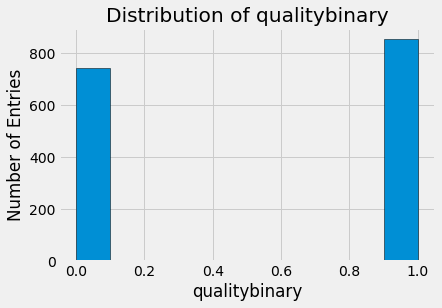

```python
df2 = df.copy()
df2['qualitybinary'] = np.where(df2['quality']>=6,1,0)
hist_chart(df2, 'qualitybinary')
```

```python
corr_data2 = df2[df2.columns[1:]].corr()['qualitybinary'][:]
sorted_corr_data2 = corr_data2.sort_values(kind="quicksort")
print(sorted_corr_data2)
```

```
volatile acidity       -0.321441
total sulfur dioxide   -0.231963
density                -0.159110
chlorides              -0.109494
free sulfur dioxide    -0.061757
pH                     -0.003264
residual sugar         -0.002160
citric acid             0.159129
sulphates               0.218072
alcohol                 0.434751
quality                 0.848279
qualitybinary           1.000000
Name: qualitybinary, dtype: float64
```

```python
num_vars_bin = df2.select_dtypes(['float64']).columns
print('Columns to check: ', num_vars_bin)
x_bin = df2[num_vars_bin]
y_bin = df2.qualitybinary

x_train_bin, x_test_bin, y_train_bin, y_test_bin = train_test_split(x_bin, y_bin, test_size=0.3, random_state=16)

scaler_bin = StandardScaler().fit(x_train_bin)
x_train_bin = scaler.transform(x_train_bin)
x_test_bin = scaler.transform(x_test_bin)

def evaluate_bin(model, graph_flag):
    out_bin = model.fit(x_train_bin, y_train_bin)
    y_pred_bin = model.predict(x_test_bin)
    cm_bin = confusion_matrix(y_test_bin, y_pred_bin)
    print ("Accuracy:", accuracy_score(y_test_bin, y_pred_bin))
    print("Precision:",metrics.precision_score(y_test_bin, y_pred_bin))
    print("Recall:",metrics.recall_score(y_test_bin, y_pred_bin))
    print("F1:", metrics.f1_score(y_test_bin,y_pred_bin))
    if graph_flag == 1:
        print ("Confusion Matrix: \n", cm_bin)
        sns.heatmap(cm_bin)
    return out_bin
```

```
Columns to check:  Index(['fixed acidity', 'volatile acidity', 'citric acid', 'residual sugar',
       'chlorides', 'free sulfur dioxide', 'total sulfur dioxide', 'density',
       'pH', 'sulphates', 'alcohol'],
      dtype='object')
```

```python
gnb_bin = GaussianNB()
gnb_train_bin = evaluate_bin(gnb_bin, 0)
```

```
Accuracy: 0.7041666666666667
Precision: 0.7142857142857143
Recall: 0.7421875
F1: 0.7279693486590038
```

```python
dtc_bin = DecisionTreeClassifier()
dtc_train_bin = evaluate_bin(dtc_bin, 0)
```

```
Accuracy: 0.7229166666666667
Precision: 0.7269372693726938
Recall: 0.76953125
F1: 0.747628083491461
```

```python
#xgb_bin = XGBClassifier()
#xgb_train_bin = evaluate_bin(xgb_bin, 0)
```

```python
rfc_bin = RandomForestClassifier(n_estimators=10)
rfc_train_bin = evaluate_bin(rfc_bin, 0)
```

```
Accuracy: 0.7479166666666667
Precision: 0.7824267782426778
Recall: 0.73046875
F1: 0.7555555555555554
```

```python
#Set up the grid search for a decision tree approach
sc = StandardScaler()
pca = decomposition.PCA()
decisiontree = tree.DecisionTreeClassifier()

# Create a pipeline for the tree
pipe = Pipeline(steps=[('sc', sc),
                       ('pca', pca),
                       ('decisiontree', decisiontree)])

#Set the parameters to test
n_components = list(range(1,x_bin.shape[1]+1,1))
criterion = ['gini', 'entropy']
max_depth = [4,6,8,12]
parameters = dict(pca__n_components=n_components,
                  decisiontree__criterion=criterion,
                  decisiontree__max_depth=max_depth)

#Check best parameters
clf_G = GridSearchCV(pipe, parameters)
clf_G.fit(x_bin, y_bin)

#View The Best Parameters
print('Best Criterion:', clf_G.best_estimator_.get_params()['decisiontree__criterion'])
print('Best max_depth:', clf_G.best_estimator_.get_params()['decisiontree__max_depth'])
print('Best Number Of Components:', clf_G.best_estimator_.get_params()['pca__n_components'])
print(); print(clf_G.best_estimator_.get_params()['decisiontree'])

#Use Cross Validation To Evaluate Model
#CV_Result = cross_val_score(clf_G, x_bin, y_bin, cv=4, n_jobs=-1)
#print(); print(CV_Result)
#print(); print(CV_Result.mean())
#print(); print(CV_Result.std())
```

```
Best Criterion: gini
Best max_depth: 6
Best Number Of Components: 10

DecisionTreeClassifier(max_depth=6)
```

```python
#Create a new algorithm based on optimized grid search parameters
clf2 = DecisionTreeClassifier(criterion="gini", max_depth=6)
clf2_train_bin = evaluate_bin(clf2, 0)
```

```
Accuracy: 0.7104166666666667
Precision: 0.7294117647058823
Recall: 0.7265625
F1: 0.7279843444227004
```

## 4.3 Regression

```python
x = inner[num_vars]
y = inner.TAC_Reading

avval = [np.mean(y) for i in y]
print('Baseline Errors')
print('Root Mean Squared Error: ',  np.sqrt(mean_squared_error(y, avval)))
print('Mean Absolute Error: ', mean_absolute_error(y, avval))
```

```
Baseline Errors
Root Mean Squared Error:  0.04573771250601856
Mean Absolute Error:  0.044197910240000006
```

```python
def evaluate_regression(mdl,mdl_name,x,y,cols):
    x_train, x_test, y_train, y_test = train_test_split(x[cols], y, test_size=0.3, random_state=16)

    scaler = StandardScaler().fit(x_train)
    x_train = scaler.transform(x_train)
    x_test = scaler.transform(x_test)


    mdl.fit(x_train,y_train)
    predicted_data = mdl.predict(x_test)
    print(mdl_name, ' using ', cols)
    print('Root Mean Squared Error: ',  np.sqrt(mean_squared_error(y_test, predicted_data)))
    print('Mean Absolute Error: ', mean_absolute_error(y_test, predicted_data))
    print('Accuracy: ', accuracy_score(y_test, predicted_data.round()))
    print()

lg = LinearRegression()
lg_name = 'Linear Regression'

# Linear regression using all columns
evaluate_regression(lg,lg_name,x,y,num_vars)

# Linear regression using higher correlation columns
t = sorted_corr_data[num_vars]
corr_cols = t[abs(t) > .2].index
evaluate_regression(lg,lg_name,x,y,corr_cols)

# Linear regression using only two most correlated columns
t = sorted_corr_data[num_vars]
corr_cols = t[abs(t) > .3].index
evaluate_regression(lg,lg_name,x,y,corr_cols)
```

```
Linear Regression  using  ['x', 'y', 'z']
Root Mean Squared Error:  0.05686621801092813
Mean Absolute Error:  0.04057559360298822
```

[output not shown]

```python
dtr = DecisionTreeRegressor()
dtr_name = 'Decision Tree Regressor'

# Linear regression using all columns
evaluate_regression(dtr,dtr_name,x,y,num_vars)

# Linear regression using higher correlation columns
t = sorted_corr_data[num_vars]
corr_cols = t[abs(t) > .2].index
evaluate_regression(dtr,dtr_name,x,y,corr_cols)

# Linear regression using only two most correlated columns
t = sorted_corr_data[num_vars]
corr_cols = t[abs(t) > .3].index
evaluate_regression(dtr,dtr_name,x,y,corr_cols)
```

[output not shown]

```python
rfr = RandomForestRegressor()
rfr_name = 'Random Forest Regressor'

# Linear regression using all columns
evaluate_regression(rfr,rfr_name,x,y,num_vars)

# Linear regression using higher correlation columns
t = sorted_corr_data[num_vars]
corr_cols = t[abs(t) > .2].index
evaluate_regression(rfr,rfr_name,x,y,corr_cols)

# Linear regression using only two most correlated columns
t = sorted_corr_data[num_vars]
corr_cols = t[abs(t) > .3].index
evaluate_regression(rfr,rfr_name,x,y,corr_cols)
```

```
Random Forest Regressor  using  ['x', 'y', 'z']
Root Mean Squared Error:  0.051702509544206736
Mean Absolute Error:  0.040280857999999996
```

[output not shown]

```python
param_grid = {'n_estimators': [n for n in range(10,200,10)],
             'max_features': ['auto','sqrt'],
             'min_samples_split': [2,5,10,20],
             'max_depth': [5,10,20,40,80]}

#Check best parameters
clf_rfr = GridSearchCV(rfr, param_grid)

x = df[num_vars]
y = df.quality

x_train, x_test, y_train, y_test = train_test_split(x, y, test_size=0.3, random_state=16)

scaler = StandardScaler().fit(x_train)
x_train = scaler.transform(x_train)
x_test = scaler.transform(x_test)


clf_rfr.fit(x_train, y_train)

#View The Best Parameters
print('Best n_estimators:', clf_rfr.best_estimator_.get_params()['n_estimators'])
print('Best max_depth:', clf_rfr.best_estimator_.get_params()['max_depth'])
print('Best min_samples_split:', clf_rfr.best_estimator_.get_params()['min_samples_split'])
print('Best max_features:', clf_rfr.best_estimator_.get_params()['max_features'])

rfr_best = clf_rfr.best_estimator_
```

```
Best n_estimators: 190
Best max_depth: 20
Best min_samples_split: 2
Best max_features: sqrt
```

```python
predicted_data = rfr_best.predict(x_test)
print('Root Mean Squared Error: ',  np.sqrt(mean_squared_error(y_test, predicted_data)))
print('Mean Absolute Error: ', mean_absolute_error(y_test, predicted_data))
print('Accuracy: ', accuracy_score(y_test, predicted_data.round()))
print(classification_report(y_test, y_pred.round()))
```

[output not shown]

In the next section we look at if we can evaluate the quality of wine with attributes that can be evaluated outside of a lab environment. Percent Alcohol is required to be included on all alcoholic beverages so we will use that, and pH testing kits can be purchased and administered at low cost so we will also use that.

```python
athome_cols = ['alcohol','pH']
evaluate_regression(lg,lg_name,x,y,athome_cols)

evaluate_regression(rfr,rfr_name,x,y,athome_cols)

evaluate_regression(dtr,dtr_name,x,y,athome_cols)
```

```
Linear Regression  using  ['alcohol', 'pH']
Root Mean Squared Error:  0.7387776615088736
Mean Absolute Error:  0.5818357616666113
Accuracy:  0.5583333333333333

Random Forest Regressor  using  ['alcohol', 'pH']
Root Mean Squared Error:  0.7737749559655775
Mean Absolute Error:  0.5786525177368927
Accuracy:  0.5333333333333333

Decision Tree Regressor  using  ['alcohol', 'pH']
Root Mean Squared Error:  0.9342654076074164
Mean Absolute Error:  0.6320138888888889
Accuracy:  0.4791666666666667
```

```python
param_grid = {'n_estimators': [n for n in range(10,200,10)],
             'max_features': [None],
             'min_samples_split': [2,5,10,20,30,40],
             'max_depth': [5,10,20,40,80,120]}

#Check best parameters
clf_rfr = GridSearchCV(rfr, param_grid)

x = df[athome_cols]
y = df.quality

x_train, x_test, y_train, y_test = train_test_split(x, y, test_size=0.3, random_state=16)

scaler = StandardScaler().fit(x_train)
x_train = scaler.transform(x_train)
x_test = scaler.transform(x_test)


clf_rfr.fit(x_train, y_train)

#View The Best Parameters
print('Best n_estimators:', clf_rfr.best_estimator_.get_params()['n_estimators'])
print('Best max_depth:', clf_rfr.best_estimator_.get_params()['max_depth'])
print('Best min_samples_split:', clf_rfr.best_estimator_.get_params()['min_samples_split'])
print('Best max_features:', clf_rfr.best_estimator_.get_params()['max_features'])

rfr_best = clf_rfr.best_estimator_
```

```
Best n_estimators: 40
Best max_depth: 5
Best min_samples_split: 5
Best max_features: None
```

```python
predicted_data = rfr_best.predict(x_test)
print('Root Mean Squared Error: ',  np.sqrt(mean_squared_error(y_test, predicted_data)))
print('Mean Absolute Error: ', mean_absolute_error(y_test, predicted_data))
print('Accuracy: ', accuracy_score(y_test, predicted_data.round()))
```

```
Root Mean Squared Error:  0.7277175865544794
Mean Absolute Error:  0.5790219895836011
Accuracy:  0.55
```

```python
def create_ann_2(activation,units):
    model = Sequential()
    model.add(Dense(units=units, activation=activation,input_shape=(11,)))
    model.add(Dense(units=units, activation=activation))
    model.add(Dense(1))
    model.compile(loss='mean_squared_error', optimizer='adam')
    return model


x = df[num_vars]
y = df.quality

x_train, x_test, y_train, y_test = train_test_split(x, y, test_size=0.3, random_state=16)

scaler = StandardScaler().fit(x_train)
x_train = scaler.transform(x_train)
x_test = scaler.transform(x_test)

param_grid = {'activation': ['relu','sigmoid','tanh'],
             'units': [5,10,15,20]}

cv = KFold(n_splits=4, shuffle=True, random_state=16)
# ANN 2
model_ann2 = KerasRegressor(build_fn=create_ann_2, epochs=16, batch_size=10,verbose=0)
grid_ann2 = GridSearchCV(estimator=model_ann2,param_grid=param_grid,cv=cv,n_jobs=-1)
grid_ann2.fit(x_train,y_train)

ann2_cv = grid_ann2.best_estimator_
y_pred = ann2_cv.predict(x_test)
```

[output not shown]

```python
print('----ANN 2 Hidden Layers----')
print('Root Mean Squared Error: ',  np.sqrt(mean_squared_error(y_test, y_pred)))
print('Mean Absolute Error: ', mean_absolute_error(y_test, y_pred))
print('Accuracy: ', accuracy_score(y_test, y_pred.round()))
print(classification_report(y_test, y_pred.round()))
print('---------------------------------')
```

```
----ANN 2 Hidden Layers----
Root Mean Squared Error:  0.6763711703540864
Mean Absolute Error:  0.5254024629791577
Accuracy:  0.55625
              precision    recall  f1-score   support

           3       0.00      0.00      0.00         3
           4       0.40      0.10      0.15        21
           5       0.64      0.58      0.61       200
           6       0.51      0.73      0.60       196
           7       0.62      0.09      0.16        56
           8       0.00      0.00      0.00         4

    accuracy                           0.56       480
   macro avg       0.36      0.25      0.25       480
weighted avg       0.56      0.56      0.52       480

---------------------------------
```